# Image Classification with Convolutional Network

## Introduction

It is time for another project in Algoritma Data Science Program. In this project, we are going to do image classification/recognition using Convulotional Neural Network that will classify whether the submitted image is a beach, a forest, or a mountain.

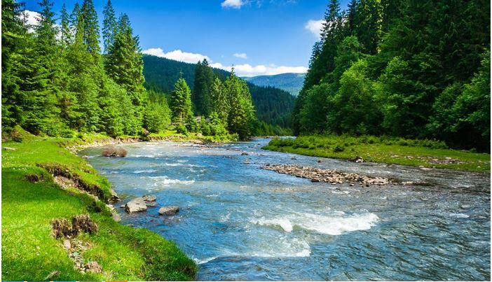

Image classification has become one of the most influencial innovations in Computer Vision since the first digital image scanner. Developing models that can classify images has made tremendous advances in the way people interact (social media, search engines & image processing), retail (both in person and online), marketing, theatre & the performing arts, government, survelance, law enforcement, etc. Thanks to image classification algorithms we are able to recieve notifications on social media when someone has posted a picture that may look like us, or object recognition in self driving cars. The idea of a program being able to identify meaningful objects in an image and make a judgement as to what it is, what it’s connected with and where it belongs based on only the information found in an image has endless applications.

In this project we explore image classification via a Convolutional Neural Network (CNN) which has become the “gold standard” for solving image classification problems. A CNN is a class of deep learning neural networks that uses a series of filters to extract features from a particular data set, while keeping parameters relatively low. CNNs analyze pixels in groups with their neighbors by sliding filters (or convolving filters) across the pixels of an image. Each filter’s purpose can be to detect various patterns within images. For example, one filter can contribute to detecting eyes in a facial recognition model; another may be responsible for detecting a nose or a mouth. Each filter essentially executes an operation on pixel data and indicates how strongly a particular feature appears in an image, where it is located and it’s frequency. This process reduces the number of parameters the CNN must learn as compared to an MLP, and does not loose spatial information. Filters change as a response to training and therefore initially begin with arbitrary values. Essentially what is being trained are these filters responsible for identifying unique features for each image or image category. Feature maps for each image are generated for each filter and provided to an activation function at the node which determines if a feature is present in a given location. This process is continued with multiple layers throughout the CNN.

In this case, we will build image classification for helping a stock photo website categorizing their image database based on the thematic location. Why is this an important task? You can check how the unsplash, a photo stock website that use deep learning to organize and create tag for each image in their collection.

[figure not shown]

“Where Were You” is a challenge for us who wish to learn more about solving problems with unstructured data from a collection of images. The data consists of images with 3 different labels: “Beach”, “Forest”, or “Mountain”. Data were collected by scraping images directly from Google image search.

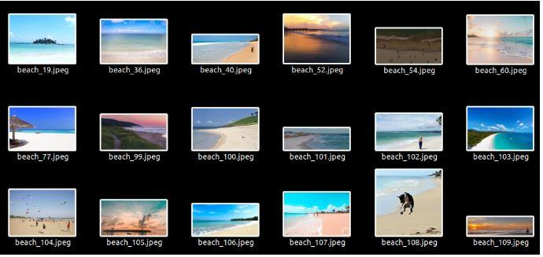

Through this dataset, we are expected to solve an image classification problem by building a model that can extract information from images and give the correct label. If you are familiar with deep learning, this is your chance to learn and implement deep learning model that is very good at dealing with unstructured data such as texts and images. Using “Where Were You” dataset, make a prediction model to classify the place captured from an image using collection of images inside the train folder. Submit your prediction for images located in the test folder. Make prediction to classify whether the image is about a `Forest`, a `Mountain`, or a `Beach`.

## Data

All image data for the data test is located inside the data/train folder.

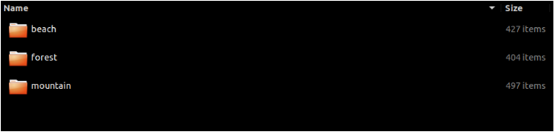

and it provide data test also to predict the image in test dataset, it located inside the data/test folder

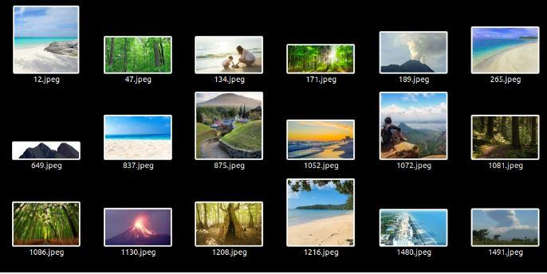

### Library and Setup

You need to install the pillow package in your conda environment to manipulate image data. Herewith some library that we used for create model, library `imager` use to load the image from the folder. Before we start better we call the library first.

```r
# Data wrangling
library(tidyverse)

# Image manipulation
library(imager)

# Deep learning
library(keras)

# Model Evaluation
library(caret)

options(scipen = 999)
```

## Exploratory Data Analysis

Let’s explore the data first before building the model. In image classification problem, it is a common practice to put each image on separate folders based on the target class/labels. For example, inside the train folder in our data, we have 3 different folders, respectively for `beach`, `forest`, and `mountain`. We have no table or any kind of structured data format, we only have the image for the beach. We will directly extract information from the images instead of using a structured dataset.

Let’s try to get the file name of each image. First, we need to locate the folder of each target class. The following code will give you the folder name inside the `train` folder.

```r
## locate the folder
folder_list <- list.files("data/train/")

folder_list
```

```
[1] "beach"    "forest"   "mountain"
```

Combine the folder name with the path or directory of the train folder in order to access the content inside each folder.

```r
## combine folder name with the path
folder_path <- paste0("data/train/", folder_list, "/")

folder_path
```

```
[1] "data/train/beach/"    "data/train/forest/"   "data/train/mountain/"
```

We will use the `map()` function to loop or iterate and collect the file name for each folder `(beach, forest, mountain)`. The `map()` will return a list so if we want to combine the file name from 3 different folders we simply use the `unlist()` function.

```r
# Get file name
file_name <- map(folder_path,
                 function(x) paste0(x, list.files(x))
                 ) %>%
  unlist()

# first 6 file name
head(file_name)
```

```
[1] "data/train/beach/beach_100.jpeg" "data/train/beach/beach_101.jpeg"
[3] "data/train/beach/beach_102.jpeg" "data/train/beach/beach_103.jpeg"
[5] "data/train/beach/beach_104.jpeg" "data/train/beach/beach_105.jpeg"
```

We can check the last 6 images.

```r
# last 6 file name
tail(file_name)
```

```
[1] "data/train/mountain/mountain_a_45.jpeg"
[2] "data/train/mountain/mountian_115.jpeg"
[3] "data/train/mountain/mountian_45.jpeg"
[4] "data/train/mountain/mountian_72.jpeg"
[5] "data/train/mountain/mountian_74.jpeg"
[6] "data/train/mountain/mountian_95.jpeg"
```

Let’s check how many images we have.

```r
length(file_name)
```

```
[1] 1328
```

To check the content of the file, we can use the `load.image()` function from the `imager package`. For example, let’s randomly visualize 6 images from the data.

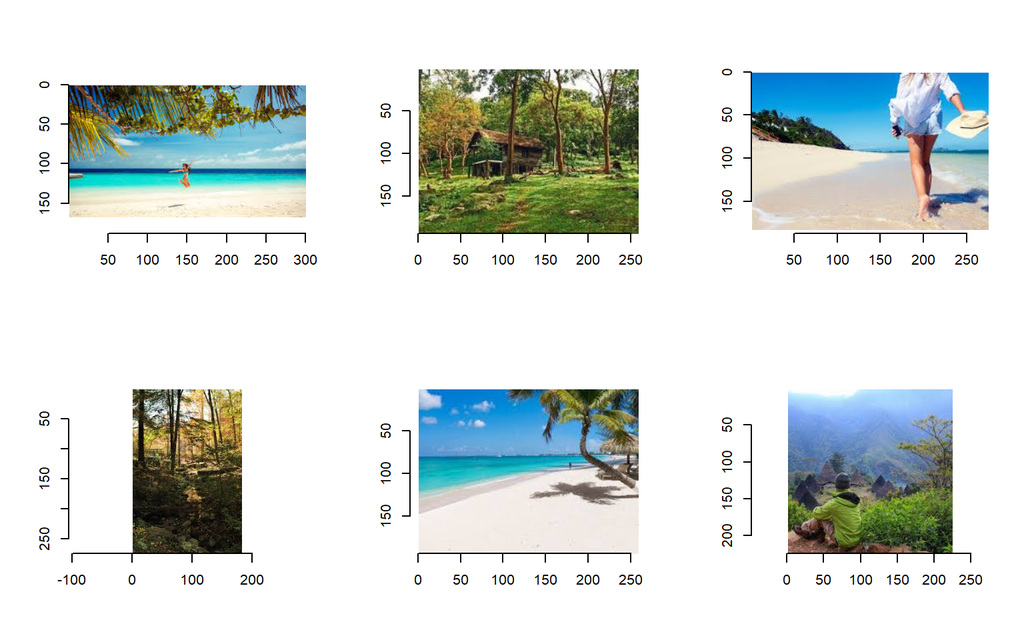

```
[[1]]
Image. Width: 300 pix Height: 168 pix Depth: 1 Colour channels: 3

[[2]]
Image. Width: 259 pix Height: 194 pix Depth: 1 Colour channels: 3

[[3]]
Image. Width: 275 pix Height: 183 pix Depth: 1 Colour channels: 3

[[4]]
Image. Width: 183 pix Height: 275 pix Depth: 1 Colour channels: 3

[[5]]
Image. Width: 259 pix Height: 194 pix Depth: 1 Colour channels: 3

[[6]]
Image. Width: 225 pix Height: 225 pix Depth: 1 Colour channels: 3
```

```r
# Randomly select image
set.seed(123)
sample_image <- sample(file_name, 6)

# Load image into R
img <- map(sample_image, load.image)

# Plot image
par(mfrow = c(2, 3)) # Create 2 x 3 image grid
map(img, plot)
```

### Check Image Dimension

One of important aspects of image classification is understand the dimension of the input images. You need to know the distribution of the image dimension to create a proper input dimension for building the deep learning model. Let’s check the properties of the first image.

```r
# Full Image Description
img <- load.image(file_name[1])
img
```

```
Image. Width: 279 pix Height: 181 pix Depth: 1 Colour channels: 3
```

```r
# Image Dimension
dim(img)
```

```
[1] 279 181   1   3
```

So we have successfully insert an image and get the image dimensions. On the following code, we will create a function that will instantly get the height and width of an image and convert it into a data.frame.

```r
# Function required to get width and height of an image
get_dim <- function(x){
  img <- load.image(x)

  df_img <- data.frame(height = height(img),
                       width = width(img),
                       filename = x
                       )

  return(df_img)
}

get_dim(file_name[1])
```

```
  height width                        filename
1    181   279 data/train/beach/beach_100.jpeg
```

Now we will get all the images from the file name and get the height and width of the image.

```r
# Randomly get 1328 sample images
set.seed(123)
sample_file <- sample(file_name)

# Run the get_dim() function for each image
file_dim <- map_df(sample_file, get_dim)

head(file_dim, 10)
```

```
   height width                              filename
1     168   300       data/train/beach/beach_518.jpeg
2     194   259     data/train/forest/forest_123.jpeg
3     183   275       data/train/beach/beach_278.jpeg
4     275   183     data/train/forest/forest_180.jpeg
5     194   259       data/train/beach/beach_294.jpeg
6     225   225 data/train/mountain/mountain_188.jpeg
7     168   300 data/train/mountain/mountain_373.jpeg
8     183   275 data/train/mountain/mountain_474.jpeg
9     208   243 data/train/mountain/mountain_488.jpeg
10    187   270 data/train/mountain/mountain_279.jpeg
```

Let’s check the statistics for the image dimensions.

```r
summary(file_dim)
```

```
     height          width         filename
 Min.   : 94.0   Min.   :100.0   Length:1328
 1st Qu.:168.0   1st Qu.:268.0   Class :character
 Median :183.0   Median :275.0   Mode  :character
 Mean   :178.2   Mean   :282.9
 3rd Qu.:184.0   3rd Qu.:300.0
 Max.   :314.0   Max.   :534.0
```

From the output result of summary statistics, we can conclude :

- The image are 3 dimensional and has great variation in the dimension.
- It has minimum height 94 pixels and maximum height 314 pixels.
- Minimum width 100 pixels and maximum width 534 pixels.

Understanding the dimension of the image will help us on the next part of the process. During data-preprocessing we have to make sure that all the images that inserted to build/train the model must have the same dimensions.

## Data Preprocessing

For data preprocessing we used data augmentation to explore more of the image, data augmentation is a technique that can be used to artificially expand the size of a training dataset by creating modified versions of images in the dataset. One of the benefit using this method it will expand the training dataset in order to improve the performance and ability of the model to generalize. Let’s explore in the following section.

### Data Augmentation

Based on our previous summary of the image dimensions, we can determine the input dimension for the deep learning model. To prepare the data for training and testing we want to keep all image dimensions consistant. Here, we can determine the `input size` for the image, at this case I transform all image into 125 x 125 pixels. I choose `125 x 125 pixels` because it is a little bit high but not to small compare with the minimum high of the image. This process will be similar to us resizing the image. You can use other choice of image dimensions, such as 64 x 64 pixels, 125 x 125 pixels or even 200 x 200 pixels. Bigger dimensions will have more features but will also take longer time to train. However, if the image size is too small, we will lose a lot of information from the data. So balancing this trade-off is the art of data preprocessing in image classification.

We also set the batch size for the data so the model will be updated every time it finished training on a single batch. Here, we set the `batch size` to `32`.

```r
# Desired height and width of images
target_size <- c(125,125)

# Batch size for training the model
batch_size <- 32
```

Since we have a little amount of training set, we will build artificial data using method called `Image Augmentation`, that we have already inform in the previous steps. Image augmentation is one useful technique in building models that can increase the size of the training set without acquiring new images. The goal is that to teach the model not only with the original image but also the modification of the image, such as flipping the image, rotate it, zooming, crop the image, etc. This will create more robust model. We can do data augmentation by using the image data generator from keras.

To do image augmentation, we can fit the data into a generator. Here, I will create the `image generator` for keras with the following parameter:

- Scaling the pixel value by dividing the pixel value by 255
- Flip the image horizontally
- Flip the image vertically
- Rotate the image from 0 to 45 degrees
- Zoom in or zoom out by 25% (zoom 75% or 125%)
- Use 20% of the data as validation dataset
- train and validation data using RGB color mode

```r
# Image Generator
train_data_gen <- image_data_generator(rescale = 1/255, # Scaling pixel value
                                       horizontal_flip = T, # Flip image horizontally
                                       vertical_flip = T, # Flip image vertically
                                       rotation_range = 45, # Rotate image from 0 to 45 degrees
                                       zoom_range = 0.25, # Zoom in or zoom out range
                                       validation_split = 0.2 # 20% data as validation data
                                       )
```

Now we can insert our image data into the generator using the `flow_images_from_directory()`. The data is located inside the data folder and inside the train folder, so the directory will be data/train. From this process, we will get the augmented image both for training data and the validation data.

```r
# Training Dataset
train_image_array_gen <- flow_images_from_directory(directory = "data/train/", # Data Folder
                                                    target_size = target_size, # image dimension(125x125px)
                                                    color_mode = "rgb", # use RGB color
                                                    batch_size = batch_size, # 32
                                                    seed = 123,  # set random seed
                                                    subset = "training", # declare this is for training data
                                                    generator = train_data_gen
                                                    )

# Validation Dataset
val_image_array_gen <- flow_images_from_directory(directory = "data/train/",
                                                  target_size = target_size,
                                                  color_mode = "rgb",
                                                  batch_size = batch_size ,
                                                  seed = 123,
                                                  subset = "validation", # declare this is for validation data
                                                  generator = train_data_gen
                                                  )
```

Here we will collect some information from the generator and check the class proportion of the train dataset. The index correspond to each labels of the target variable and ordered alphabetically `(beach, forest, mountain)`.

```r
# Number of training samples
train_samples <- train_image_array_gen$n

# Number of validation samples
valid_samples <- val_image_array_gen$n

# Number of target classes/categories
output_n <- n_distinct(train_image_array_gen$classes)

# Get the class proportion
table("\nFrequency" = factor(train_image_array_gen$classes)
      ) %>%
  prop.table()
```

```
Frequency
        0         1         2
0.3214286 0.3045113 0.3740602
```

From the output the proportion in each class is quite balance which is around 30% in each class. We have to make sure the proportion of the class balance because when class imbalance exists within training data, learners will typically over-classify the majority group due to its increased prior probability. As a result, the instances belonging to the minority group are misclassified more often than those belonging to the majority group. We are looking forward into the next steps for building the model using Convolutional Neural Network.

## Convolutional Neural Network

A Convolutional Neural Network (ConvNet/CNN) is a Deep Learning algorithm which can take in an input image, assign importance (learnable weights and biases) to various aspects/objects in the image and be able to differentiate one from the other. The pre-processing required in a ConvNet is much lower as compared to other classification algorithms. While in primitive methods filters are hand-engineered, with enough training, ConvNets have the ability to learn these filters/characteristics. Below the visualization of the CNN architecture.

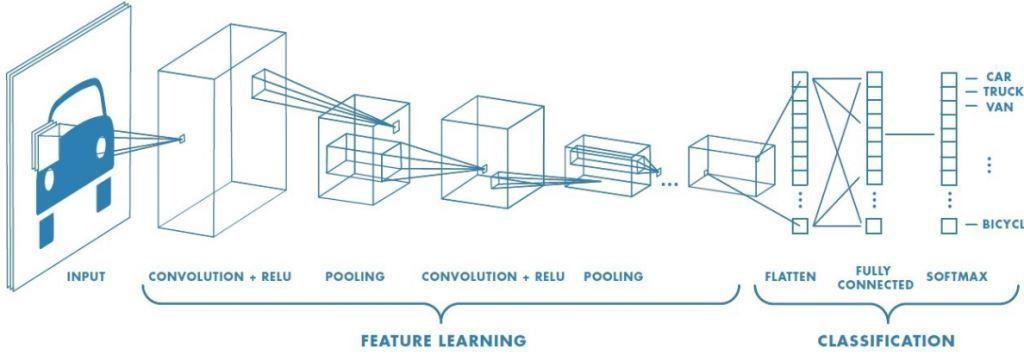

The architecture of a ConvNet is analogous to that of the connectivity pattern of Neurons in the Human Brain and was inspired by the organization of the Visual Cortex. Individual neurons respond to stimuli only in a restricted region of the visual field known as the Receptive Field. A collection of such fields overlap to cover the entire visual area.

### Model Architecture

We can start building the model architecture for the deep learning. We will build a simple model first with the following layer:

- Layer One - Input Layer : Convolutional layer to extract features from 2D image with 32 3x3 filters, ReLU activation function and input dimensions of 125 x 125 x 3.
- Layer Two : Max Pooling layer to downsample the image features with size filter 2x2
- Layer Three : Flattening layer to flatten data from 2D array to 1D array, transforms matrix into vector for fully connected layer
- Layer Four : Dense layer to capture more information with 32 neurons and ReLU activation function
- Layer Five - Output Layer : Fully connected layer with 3 neurons (because we have 3 categories) and a softmax activation function for probability output.

Don’t forget to set the input size in the first layer. If the input image is in RGB, set the final number to 3, which is the number of color channels. If the input image is in grayscale, set the final number to 1.

```r
# input shape of the image
c(target_size, 3)
```

```
[1] 125 125   3
```

```r
# Set Initial Random Weight
tensorflow::tf$random$set_seed(123)

model <- keras_model_sequential(name = "simple_model") %>%

  # Convolution Layer
  layer_conv_2d(filters = 32,
                kernel_size = c(3,3),
                padding = "same",
                activation = "relu",
                input_shape = c(target_size, 3)
                ) %>%

  # Max Pooling Layer
  layer_max_pooling_2d(pool_size = c(2,2)) %>%

  # Flattening Layer
  layer_flatten() %>%

  # Dense Layer
  layer_dense(units = 32,
              activation = "relu") %>%

  # Output Layer
  layer_dense(units = output_n,
              activation = "softmax",
              name = "Output")

model
```

```
Model
Model: "simple_model"
________________________________________________________________________________
Layer (type)                        Output Shape                    Param #
================================================================================
conv2d (Conv2D)                     (None, 125, 125, 32)            896
________________________________________________________________________________
max_pooling2d (MaxPooling2D)        (None, 62, 62, 32)              0
________________________________________________________________________________
flatten (Flatten)                   (None, 123008)                  0
________________________________________________________________________________
dense (Dense)                       (None, 32)                      3936288
________________________________________________________________________________
Output (Dense)                      (None, 3)                       99
================================================================================
Total params: 3,937,283
Trainable params: 3,937,283
Non-trainable params: 0
________________________________________________________________________________
```

### Model Fitting

At the augmentation part I have already do cross validation of the data train and validation dataset. Cross-validation is primarily used in applied machine learning to estimate the skill of a machine learning model on unseen data. That is, to use a limited sample in order to estimate how the model is expected to perform in general when used to make predictions on data not used during the training of the model, at this case I make it 80% for data train and 20% for validation dataset. Using the `compile()` function we can configure the CNN and specify the followng parameters:

- *Loss Function* - `categorical_crossentropy` is used because each image can only belong to one category, and for multilabel classification.
- *Optimizer* - `optimizer_sgd()` first simple model I’m using sgd optimizer with learning rate of 0.001. SGD optimizer implements the stochastic gradient descent optimizer with a learning rate and momentum.
- *Metrics* : here we specify that we want the model evaluated for accuracy of categorization.

For starter, we will use 30 epochs to train the data. We will also evaluate the model with the validation data from the generator.

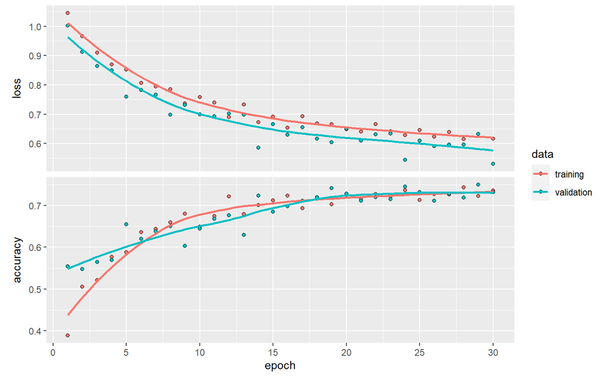

```r
model %>%
  compile(
    loss = "categorical_crossentropy",
    optimizer = optimizer_sgd(learning_rate =  0.001),
    metrics = "accuracy"
  )

# Fit data into model
history <- model %>%
  fit_generator(
#  training data
  train_image_array_gen,

  # training epochspp
  steps_per_epoch = as.integer(train_samples / batch_size),
  epochs = 30,

  # validation data
  validation_data = val_image_array_gen,
  validation_steps = as.integer(valid_samples / batch_size)
)

plot(history)
```

### Model Evaluation

Now we will further evaluate and acquire the confusion matrix using the validation data from the generator. First, we need to acquire the file name of the image that is used as the data validation. From the file name, we will extract the categorical label as the actual value of the target variable.

```r
val_data <- data.frame(file_name = paste0("data/train/", val_image_array_gen$filenames)) %>%
  mutate(class = str_extract(file_name, "beach|forest|mountain"))

head(val_data, 10)
```

```
                          file_name class
1  data/train/beach\\beach_100.jpeg beach
2  data/train/beach\\beach_101.jpeg beach
3  data/train/beach\\beach_102.jpeg beach
4  data/train/beach\\beach_103.jpeg beach
5  data/train/beach\\beach_104.jpeg beach
6  data/train/beach\\beach_105.jpeg beach
7  data/train/beach\\beach_106.jpeg beach
8  data/train/beach\\beach_107.jpeg beach
9  data/train/beach\\beach_108.jpeg beach
10 data/train/beach\\beach_109.jpeg beach
```

What to do next? We need to get the image into R by converting the image into an array. Since our input dimension for CNN model is image with 125 x 125 pixels with 3 color channels (RGB), we will do the same with the image of the testing data. The reason of using array is that we want to predict the original image fresh from the folder so we will not use the image generator since it will transform the image and does not reflect the actual image.

```r
# Function to convert image to array
image_prep <- function(x) {
  arrays <- lapply(x, function(path) {
    img <- image_load(path, target_size = target_size,
                      grayscale = F # Set FALSE if image is RGB
                      )

    x <- image_to_array(img)
    x <- array_reshape(x, c(1, dim(x)))
    x <- x/255 # rescale image pixel
  })
  do.call(abind::abind, c(arrays, list(along = 1)))
}
```

```r
test_x <- image_prep(val_data$file_name)

# Check dimension of testing data set
dim(test_x)
```

```
[1] 264 125 125   3
```

The validation data consists of 264 images with dimensions of 125 x 125 pixels and 3 color channels (RGB). After we have prepared the data test, we now can proceed to predict the label of each image using our CNN model.

```r
pred_test <- predict_classes(model, test_x)

head(pred_test, 10)
```

```
 [1] 0 0 0 2 0 0 0 0 0 0
```

To get easier interpretation of the prediction, we will convert the encoding into proper class label.

```r
# Convert encoding to label
decode <- function(x){
  case_when(x == 0 ~ "beach",
            x == 1 ~ "forest",
            x == 2 ~ "mountain"
            )
}

pred_test <- sapply(pred_test, decode)

head(pred_test, 10)
```

```
 [1] "beach"    "beach"    "beach"    "mountain" "beach"    "beach"
 [7] "beach"    "beach"    "beach"    "beach"
```

```r
confusionMatrix(as.factor(pred_test),
                as.factor(val_data$class)
                )
```

```
Confusion Matrix and Statistics

          Reference
Prediction beach forest mountain
  beach       68      1       23
  forest       0     66        9
  mountain    17     13       67

Overall Statistics

               Accuracy : 0.7614
                 95% CI : (0.7053, 0.8115)
    No Information Rate : 0.375
    P-Value [Acc > NIR] : <0.0000000000000002

                  Kappa : 0.6406

 Mcnemar's Test P-Value : 0.4527

Statistics by Class:

                     Class: beach Class: forest Class: mountain
Sensitivity                0.8000        0.8250          0.6768
Specificity                0.8659        0.9511          0.8182
Pos Pred Value             0.7391        0.8800          0.6907
Neg Pred Value             0.9012        0.9259          0.8084
Prevalence                 0.3220        0.3030          0.3750
Detection Rate             0.2576        0.2500          0.2538
Detection Prevalence       0.3485        0.2841          0.3674
Balanced Accuracy          0.8330        0.8880          0.7475
```

If we look at the result , we got a pretty good accuracy with `76.14% accuracy`. We found also that there are not really good results with another metrics. Some are good, but some are low.

Since our target is accuracy,sensitivity, specifity and precision > 75%, we need to improve the model to get better accuracy and another metrics. The model is in good fit, not overfit since the accuracy both using train data and test data is having almost the same result.

Now let us check if we can improve the accuracy or another metrics with model tuning.

## Model Improvement

### Model Architecture

Let’s look back at our model architecture. If you have noticed, we can actually extract more information while the data is still in an 2D image array. The first CNN only extract the general features of our image and then being downsampled using the max pooling layer. Even after pooling, we still have 62 x 62 array that has a lot of information to extract before flattening the data. Therefore, we can stacks more CNN layers into the model so there will be more information to be captured. We can also put 2 CNN layers consecutively before doing max pooling.

```r
model
```

```
Model
Model: "simple_model"
________________________________________________________________________________
Layer (type)                        Output Shape                    Param #
================================================================================
conv2d (Conv2D)                     (None, 125, 125, 32)            896
________________________________________________________________________________
max_pooling2d (MaxPooling2D)        (None, 62, 62, 32)              0
________________________________________________________________________________
flatten (Flatten)                   (None, 123008)                  0
________________________________________________________________________________
dense (Dense)                       (None, 32)                      3936288
________________________________________________________________________________
Output (Dense)                      (None, 3)                       99
================================================================================
Total params: 3,937,283
Trainable params: 3,937,283
Non-trainable params: 0
________________________________________________________________________________
```

Herewith the parameter of the model architecture improvement:

- 1st Convolutional layer to extract features from 2D image with 32 3x3 filters, relu activation function
- 2nd Convolutional layer to extract features from 2D image with 32 3x3 filters, relu activation function
- Max pooling layer with size filter 2 x 2
- 3rd Convolutional layer to extract features from 2D image with 64 3x3 filters, relu activation function
- Max pooling layer with size filter 2 x 2
- 4th Convolutional layer to extract features from 2D image with 128 3x3 filters, relu activation function
- Max pooling layer with size filter 2 x 2
- 5th Convolutional layer to extract features from 2D image with 256 3x3 filters, relu activation function
- Max pooling layer with size filter 2 x 2
- Flattening layer from 2D array to 1D array
- Dense layer to capture more information with 64 neurons and ReLU activation function
- Dense layer for output layer with 3 neurons (because we have 3 categories) and a softmax activation function for probability output.

You can play and get creative by designing your own model architecture.

```r
# Set Initial Random Weight
tensorflow::tf$random$set_seed(123)

model_tuned <- keras_model_sequential(name = "model_tuned") %>%

  # Convolution Layer
  layer_conv_2d(filters = 32,
                kernel_size = c(3,3),
                padding = "same",
                activation = "relu",
                input_shape = c(target_size, 3)
                ) %>%
  # Convolution Layer
  layer_conv_2d(filters = 32,
                kernel_size = c(3,3),
                padding = "same",
                activation = "relu",
                input_shape = c(target_size, 3)
                ) %>%

  # Max Pooling Layer
  layer_max_pooling_2d(pool_size = c(2,2)) %>%


  # Convolutional layer
  layer_conv_2d(filters = 64,
                kernel_size = c(3,3),
                padding = "same",
                activation = "relu"
                ) %>%

  # Max pooling layer
  layer_max_pooling_2d(pool_size = c(2,2)) %>%

  # Convolutional layer
  layer_conv_2d(filters = 128,
                kernel_size = c(3,3),
                padding = "same",
                activation = "relu"
                ) %>%

  # Max pooling layer
  layer_max_pooling_2d(pool_size = c(2,2)) %>%

   # Convolutional layer
  layer_conv_2d(filters = 256,
                kernel_size = c(3,3),
                padding = "same",
                activation = "relu"
                ) %>%

  # Max pooling layer
  layer_max_pooling_2d(pool_size = c(2,2)) %>%


  # Flattening Layer
  layer_flatten() %>%

  # Dense Layer
  layer_dense(units = 64,
              activation = "relu") %>%

  # Output Layer
  layer_dense(units = output_n,
              activation = "softmax",
              name = "Output")

model_tuned
```

```
Model
Model: "model_tuned"
________________________________________________________________________________
Layer (type)                        Output Shape                    Param #
================================================================================
conv2d_5 (Conv2D)                   (None, 125, 125, 32)            896
________________________________________________________________________________
conv2d_4 (Conv2D)                   (None, 125, 125, 32)            9248
________________________________________________________________________________
max_pooling2d_4 (MaxPooling2D)      (None, 62, 62, 32)              0
________________________________________________________________________________
conv2d_3 (Conv2D)                   (None, 62, 62, 64)              18496
________________________________________________________________________________
max_pooling2d_3 (MaxPooling2D)      (None, 31, 31, 64)              0
________________________________________________________________________________
conv2d_2 (Conv2D)                   (None, 31, 31, 128)             73856
________________________________________________________________________________
max_pooling2d_2 (MaxPooling2D)      (None, 15, 15, 128)             0
________________________________________________________________________________
conv2d_1 (Conv2D)                   (None, 15, 15, 256)             295168
________________________________________________________________________________
max_pooling2d_1 (MaxPooling2D)      (None, 7, 7, 256)               0
________________________________________________________________________________
flatten_1 (Flatten)                 (None, 12544)                   0
________________________________________________________________________________
dense_1 (Dense)                     (None, 64)                      802880
________________________________________________________________________________
Output (Dense)                      (None, 3)                       195
================================================================================
Total params: 1,200,739
Trainable params: 1,200,739
Non-trainable params: 0
________________________________________________________________________________
```

### Model Fitting

We can once again fit the model into the data. I will let the data train with more epochs since we have small numbers of data, in this case I will train the data with 100 epochs, it is much steps and take longer time to process, and I will use adam optimizer with learning rate of 0.001 which is found to be the optimal learning rate for this data.

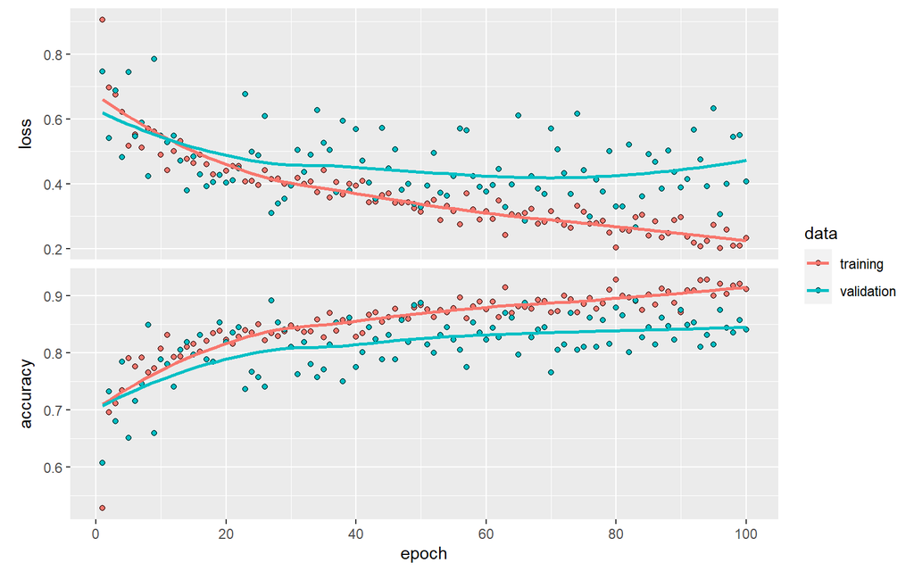

```r
model_tuned %>%
  compile(
    loss = "categorical_crossentropy",
    optimizer = optimizer_adam(learning_rate = 0.001),
    metrics = "accuracy"
  )

# Fit data into model
history <- model_tuned %>%
  fit_generator(
#  training data
  train_image_array_gen,

  # training epoch
  steps_per_epoch = as.integer(train_samples / batch_size),
  epochs = 100,

  # validation data
  validation_data = val_image_array_gen,
  validation_steps = as.integer(valid_samples / batch_size)
)

plot(history)
```

### Model Evaluation

Now we will further evaluate the data and acquire the confusion matrix for the validation data.

```r
pred_test <- predict_classes(model_tuned, test_x)

head(pred_test,10)
```

```
 [1] 0 0 0 0 0 0 0 0 0 0
```

To get easier interpretation of the prediction, we will convert the encoding into proper class label.

```r
# Convert encoding to label
decode <- function(x){
  case_when(x == 0 ~ "beach",
            x == 1 ~ "forest",
            x == 2 ~ "mountain"
            )
}

pred_test <- sapply(pred_test, decode)

head(pred_test,10)
```

```
 [1] "beach" "beach" "beach" "beach" "beach" "beach" "beach" "beach" "beach"
[10] "beach"
```

Finally, we evaluate the model using the confusion matrix. This model perform better than the previous model because we put more CNN layer to extract more features from the image.

```r
confusionMatrix(as.factor(pred_test),
                as.factor(val_data$class)
                )
```

```
Confusion Matrix and Statistics

          Reference
Prediction beach forest mountain
  beach       79      0        9
  forest       0     73        8
  mountain     6      7       82

Overall Statistics

               Accuracy : 0.8864
                 95% CI : (0.8418, 0.922)
    No Information Rate : 0.375
    P-Value [Acc > NIR] : < 0.00000000000000022

                  Kappa : 0.8291

 Mcnemar's Test P-Value : NA

Statistics by Class:

                     Class: beach Class: forest Class: mountain
Sensitivity                0.9294        0.9125          0.8283
Specificity                0.9497        0.9565          0.9212
Pos Pred Value             0.8977        0.9012          0.8632
Neg Pred Value             0.9659        0.9617          0.8994
Prevalence                 0.3220        0.3030          0.3750
Detection Rate             0.2992        0.2765          0.3106
Detection Prevalence       0.3333        0.3068          0.3598
Balanced Accuracy          0.9396        0.9345          0.8747
```

Let’s check the accuracy between data train and validation dataset :

```r
# accuracy in data train
history$metrics$accuracy[100]
```

```
[1] 0.9118217
```

```r
# accuracy in validation dataset
history$metrics$val_accuracy[100]
```

```
[1] 0.8405172
```

## Prediction in Testing Dataset

### Load Data Image & Data Preprocessing

After we have trained the model improvement and it is quite satisfied with the model performance on the validation dataset, we will do another model evaluation using the testing dataset. The testing data is located on the test folder. Let’s us load the image and processing the data test first before evaluated the model.

```r
# Load data test
folder_list_test <- list.files("data/test/")
folder_path_test <- paste0("data/test/", folder_list_test,"/")

# Get file name
file_name_test <- map(folder_path_test,
                 function(x) paste0(x, list.files(x))
                 ) %>%
unlist()

head(file_name_test)
```

```
[1] "data/test/testimages/10107.jpeg" "data/test/testimages/10238.jpeg"
[3] "data/test/testimages/10330.jpeg" "data/test/testimages/1052.jpeg"
[5] "data/test/testimages/10626.jpeg" "data/test/testimages/1072.jpeg"
```

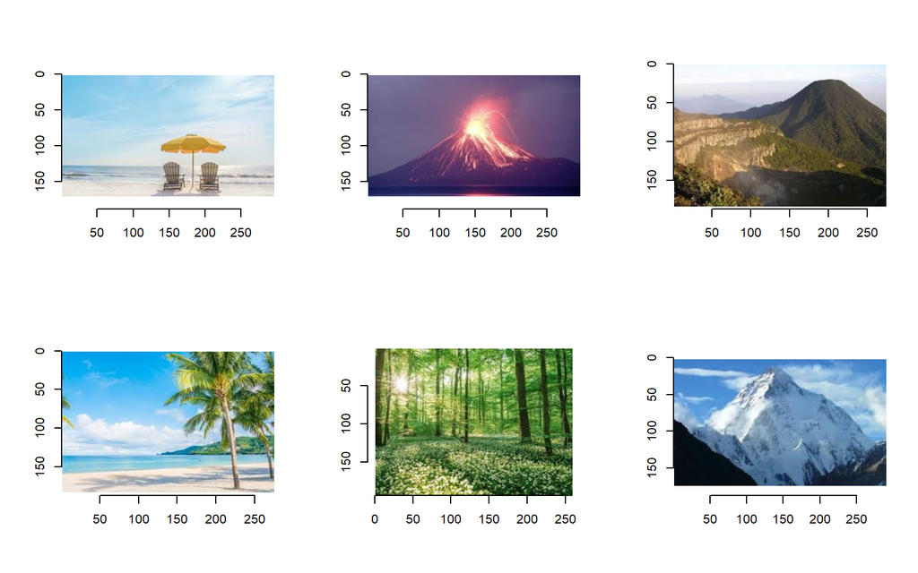

```
[[1]]
Image. Width: 296 pix Height: 170 pix Depth: 1 Colour channels: 3

[[2]]
Image. Width: 296 pix Height: 170 pix Depth: 1 Colour channels: 3

[[3]]
Image. Width: 274 pix Height: 184 pix Depth: 1 Colour channels: 3

[[4]]
Image. Width: 275 pix Height: 183 pix Depth: 1 Colour channels: 3

[[5]]
Image. Width: 259 pix Height: 194 pix Depth: 1 Colour channels: 3

[[6]]
Image. Width: 290 pix Height: 174 pix Depth: 1 Colour channels: 3
```

```r
#Check Contain Randomly select image from data test
set.seed(123)
sample_image_test <- sample(file_name_test, 6)

# Load image into R
img_test <- map(sample_image_test, load.image)

# Plot image
par(mfrow = c(2, 3)) # Create 2 x 3 image grid
map(img_test, plot)
```

```r
# Function for acquiring width and height of an image
get_dim <- function(x){
  img <- load.image(x)

  df_img <- data.frame(height = height(img),
                       width = width(img),
                       filename = x
                       )

  return(df_img)
}

set.seed(123)
sample_file_test <- sample(file_name_test)

# Run the get_dim() function for each image
file_dim_test <- map_df(sample_file_test, get_dim)

head(file_dim_test, 10)
```

```
   height width                        filename
1     170   296 data/test/testimages/27248.jpeg
2     170   296  data/test/testimages/1130.jpeg
3     184   274 data/test/testimages/28382.jpeg
4     183   275 data/test/testimages/21204.jpeg
5     194   259 data/test/testimages/32181.jpeg
6     174   290  data/test/testimages/4160.jpeg
7     100   100  data/test/testimages/9893.jpeg
8     159   318 data/test/testimages/24001.jpeg
9     162   311  data/test/testimages/1815.jpeg
10    183   275 data/test/testimages/18287.jpeg
```

```r
summary(file_dim_test)
```

```
     height          width         filename
 Min.   :100.0   Min.   :100.0   Length:294
 1st Qu.:168.0   1st Qu.:273.2   Class :character
 Median :183.0   Median :275.0   Mode  :character
 Mean   :179.3   Mean   :275.8
 3rd Qu.:183.0   3rd Qu.:300.0
 Max.   :300.0   Max.   :450.0
```

From the summary statistics output result, we can conclude as below :

- Our image data has a great variation in the dimension
- The minimum height is 100 pixels while the maximum height is 300 pixels
- The minimum width is 100 pixels while the maximum width is up to 450 pixels

During prediction using data test, we have to make sure that all the images that inserted to the model must have the same dimensions.

```r
# #Image Generator
# test_data_gen <- image_data_generator(rescale = 1/255, # Scaling pixel value
#                                        horizontal_flip = T, # Flip image horizontally
#                                        vertical_flip = T, # Flip image vertically
#                                        rotation_range = 45, # Rotate image from 0 to 45 degrees
#                                        zoom_range = 0.25) # Zoom in or zoom out range
#
# test_image_array_gen <- flow_images_from_directory(directory = "data/test/",
#                                                   target_size = target_size,
#                                                   color_mode = "rgb",
#                                                   batch_size = batch_size ,
#                                                   seed = 123,
#                                                   generator = test_data_gen)
#
```

### Prediction

```r
# create data frame from the image list
test_data <- data.frame(file_name = paste0(file_name_test)) %>%
  mutate(class = str_extract(file_name, "beach|forest|mountain"))

head(test_data, 10)
```

```
                         file_name class
1  data/test/testimages/10107.jpeg  <NA>
2  data/test/testimages/10238.jpeg  <NA>
3  data/test/testimages/10330.jpeg  <NA>
4   data/test/testimages/1052.jpeg  <NA>
5  data/test/testimages/10626.jpeg  <NA>
6   data/test/testimages/1072.jpeg  <NA>
7  data/test/testimages/10751.jpeg  <NA>
8   data/test/testimages/1081.jpeg  <NA>
9   data/test/testimages/1086.jpeg  <NA>
10 data/test/testimages/11001.jpeg  <NA>
```

```r
test1 <- image_prep(test_data$file_name)

# Check dimension of testing data set
dim(test1)
```

```
[1] 294 125 125   3
```

```r
pred_test1 <- predict_classes(model_tuned, test1)

head(pred_test1, 10)
```

```
 [1] 0 1 2 0 2 2 2 1 1 2
```

To get easier interpretation of the prediction, we will convert the encoding into proper class label.

```r
# Convert encoding to label
decode <- function(x){
  case_when(x == 0 ~ "beach",
            x == 1 ~ "forest",
            x == 2 ~ "mountain"
            )
}

pred_test2 <- sapply(pred_test1, decode)

head(pred_test2,10)
```

```
 [1] "beach"    "forest"   "mountain" "beach"    "mountain" "mountain"
 [7] "mountain" "forest"   "forest"   "mountain"
```

```r
submission <- read.csv("data/submission-example.csv")
submission$label <- pred_test2
head(submission)
```

```
          id    label
1 10107.jpeg    beach
2 10238.jpeg   forest
3 10330.jpeg mountain
4  1052.jpeg    beach
5 10626.jpeg mountain
6  1072.jpeg mountain
```

### Submission

```r
# Write submission
write.csv(submission, "submission-rachma.csv", row.names = F)

# check first 3 data
head(submission)
```

```
          id    label
1 10107.jpeg    beach
2 10238.jpeg   forest
3 10330.jpeg mountain
4  1052.jpeg    beach
5 10626.jpeg mountain
6  1072.jpeg mountain
```

Herewith the leaderboard score result still in range of the requirement value :

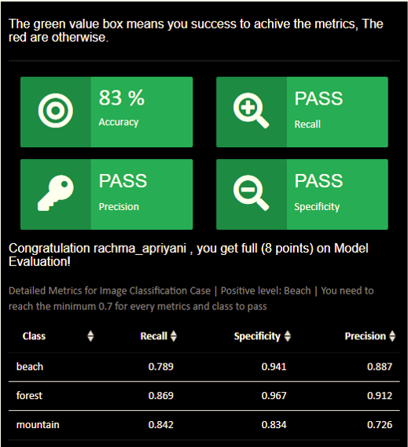

Save model improvement using `save model tf()` function :

```r
# save model
save_model_tf(model_tuned, filepath = "modelcnn_capstone_rachma")
```

```r
# load model
model_tuned <- load_model_tf("modelcnn_capstone_rachma")
```

```r
# check model
summary(model_tuned)
```

```
Model: "model_tuned"
________________________________________________________________________________
Layer (type)                        Output Shape                    Param #
================================================================================
conv2d_5 (Conv2D)                   (None, 125, 125, 32)            896
________________________________________________________________________________
conv2d_4 (Conv2D)                   (None, 125, 125, 32)            9248
________________________________________________________________________________
max_pooling2d_4 (MaxPooling2D)      (None, 62, 62, 32)              0
________________________________________________________________________________
conv2d_3 (Conv2D)                   (None, 62, 62, 64)              18496
________________________________________________________________________________
max_pooling2d_3 (MaxPooling2D)      (None, 31, 31, 64)              0
________________________________________________________________________________
conv2d_2 (Conv2D)                   (None, 31, 31, 128)             73856
________________________________________________________________________________
max_pooling2d_2 (MaxPooling2D)      (None, 15, 15, 128)             0
________________________________________________________________________________
conv2d_1 (Conv2D)                   (None, 15, 15, 256)             295168
________________________________________________________________________________
max_pooling2d_1 (MaxPooling2D)      (None, 7, 7, 256)               0
________________________________________________________________________________
flatten_1 (Flatten)                 (None, 12544)                   0
________________________________________________________________________________
dense_1 (Dense)                     (None, 64)                      802880
________________________________________________________________________________
Output (Dense)                      (None, 3)                       195
================================================================================
Total params: 1,200,739
Trainable params: 1,200,739
Non-trainable params: 0
________________________________________________________________________________
```

## Conclusion

As shown in this project, CNN implementation for image classification for arbitrary images of beach, forest and mountain is possible with few lines of code. Keras provides a simple way to implement multiple types of CNN architectures and facilitates easy fine tunning of hyperparameters so that models can be easily optimized. Finally I used model improvement to predit the dataset, and the result better than simple model. The accuracy of the improvement model is significantly increase than the simple model after we adjust the architecture of the model, but it took longer time to train due to I used 100 epoch, more epoch used more time it takes, better create GPU in your laptop than CPU, I think it’s safe time to do the train process. This does not tells us whether the model specification is optimal, we can still try in obtaining a better model performance using other method or adjusting the network architecture. Many benefit we can take to use machine learning with convolutional neural networks, from this project case we can implement to classify photo collection in the website, users no longer needed to tag photos with labels like `beach`, `forest`, or `mountain` to categorize image content. We can explore for the collection of photos in new ways, using search terms to locate photos with objects they might never have tagged. For example, they could search for `beach` to surface all their vacation photos that had beach in the background, and many more.